# MUM 2023-24 Modele rekurencyjnych sieci neuronowych

## stany ukryte

- niech token $x_t$ zależy od n-1 poprzedzających tokenów
- wtedy trzeba zapamiętać $\mid V\mid^n$ wartosci dla słownika V
- zamiast modelować $P(x_t\mid x_{t-1},\dots,x_1)$ lepiej zbudować model z przestrzenią **latent** aby $P(x_t\mid x_{t-1},\dots,x_1)\approx{}P(x_t\mid h_{t-1})$ gdzie $$h_t=f(x_t,h_{t-1})$$
  - przybliżenie jest dobre dla odpowiednio mocnej $f$

### RNN jako sieć neuronowa **bez ukrytych stanów**

- prosty MLP z warstwą ukrytą $$\begin{align} H&=\phi(X W_{x-h}+b_h)\\ O&=HW_{h-q}+b_q \end{align}$$
  - gdzie $X\in\mathbb{R}^{n\times{}d}$ dla batcha o długości n, o d wejściach
    - $x$ - wejścia, $h$ -- warstwa ukryta, latent, $q$ - wyjścia
  - warstwa ukryta $H\in\mathbb{R}^{n\times{}h}$
    - służy do przetworzenia całego batcha
  - wagi wejście - stan ukryty $W_{x-h}\in\mathbb{R}^{d\times{}h}$
  - wagi stan ukryty - wyjście $W_{h-q}\in\mathbb{R}^{h\times{}q}$ o q wyjściach

### RNN jako sieć **z ukrytym stanem**

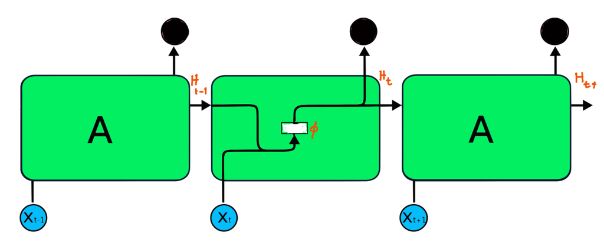

- niech $X_t$ będzie mini-batchem w chwili t $$\begin{align} H_t&=\phi(X_t W_{x-h} + H_{t-1}W_{h-h} + b_h)\\ O_t&=H_tW_{h-q}+b_q \end{align}$$
  - warstwa (stan) latent $H_t$ jest teraz **przechowywana** do następnego kroku
  - wagi $W_{h-h}\in\mathbb{R}^{h\times{}h}$ przetwarzają stan ukryty w nową wartość w kolejnym kroku
    - wartość zależy od połączonych aktualnego wejścia i poprzedniego stanu - obliczenia są **rekurencyjne**
- dla modelu językowego i tokenów w postaci słów
  - model zwraca w każdym kroku kolejne najbardziej prawdopodobne słowo

## reprezentacja wejścia dla modelu językowego

- często reprezentacja jest one-hot, jednak dla słownika jest to niewykonalne (tzw. **curse of dimensionality**)
  - reprezentacja jako indeks w słowniku, np. pozycja w tabeli częstości? trochę bez sensu
- możliwa reprezentacja jako **rozproszony wektor cech** [[Bengio, Ducharme, Vincent, Jauvin, *A neural probabilistic language model*, 2003]](https://www.jmlr.org/papers/volume3/bengio03a/bengio03a.pdf)
  - mapowanie indeksu $i\in{}V$ do m-wymiarowego wektora cech $C(i)\in\mathbb{R}^m$
- reprezentacja przez cechy powinna mieć własność, że podobne słowa mają podobne reprezentacje przez cechy Autoenkoder

## uczenie

- uczenie przez wiele warstw może spowodować niestabilność numeryczną
  - wiele warstw, wiele kroków przez latent
  - zanikający i wybuchający gradient

### problemy

- w każdym kroku $w\leftarrow{}w-\eta g$ gdzie $g$ jest gradientem
- niech funkcja celu będzie wystarczająco gładka, wtedy spełnia warunek Lipschitza dla stałej L $$\mid{}f(w)-f(w')\mid\leq{}L\|w-w'\|$$
  - dla poprawianych wektorów parametrów $$\mid{}f(w)-f(w-\eta{}g)\mid\leq{}L\|w-(w-\eta g)\|=L\eta\|g\|$$
  - dla ciągłości, wartość funkcji nie może się zmienić więc niż o $L\eta\|g\|$
  - wartość $\|g\|$ może wybuchnąć, stąd prostym rozwiązaniem może być **ograniczanie** tego wzrostu
    - można ograniczyć wartość $\eta$, co jednak spowoduje ograniczenie prędkości zawsze
    - alternatywą może być ograniczanie (**clipping**) wektora poprawki, jeśli przekroczy jakiś próg, np. $$g=\min\left(1, \theta/\|g\|\right)$$
    - to oczywiście jest jakieś hackowanie kodu, nie pełne rozwiązanie, ale jest proste i często działa

## Backpropagation Through Time BPTT

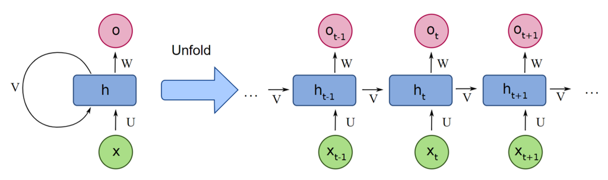

- model musi przejść wiele kroków przez wszystkie $(x_{t-1},\dots,x_{t-\tau})$
- błąd we wstecznej propagacji jest zależny od **wszystkich** wejść, wszystkich aktywacji wektora stanu, błędów pomiędzy kolejnymi aktywacjami stanu, które **wszystkie są zależne od siebie**
  - stąd rozwinięcie modelu w listę równoważną głębokiej sieci neuronowej, z tym, że wagi $W_{h}$ (zamiast $W_{h-h}$ jak wcześniej) są **dzielone**
    - lista może być długa - problemy pamięciowe i numeryczne
- aktualizacja stanu i wyjścia w kroku t $$\begin{align} h_t&=f(x_t, h_{t-1}, w_h)\\ o_t&=g(h_t, w_o) \end{align}$$ dający listę $$\dots,(x_{t-1},h_{t-1},o_{t-1}), (x_{t},h_{t},o_{t}),\dots$$
- każde przejście daje błąd, stąd całkowity błąd po wszystkich krokach $$L(x_1,\dots,x_T,y_1,\dots,y_T, w_h,w_o)=\dfrac{1}{T}\sum_{t=1}^Tl_t(y_t,o_t)$$
  - policzenie gradientu funkcji kosztu po wadze $w_h$ jest proste $$\begin{align} \dfrac{\partial L}{\partial w_h}=\dfrac{1}{T}\sum_{t=1}^T\dfrac{\partial l(y_t,o_t)}{\partial w_h}=\dfrac{1}{T}\sum_{t=1}^T\dfrac{\partial l(y_t)}{\partial o_t}\dfrac{\partial g(h_t,w_o)}{\partial h_t}\dfrac{\partial h_t}{\partial w_h} \end{align}$$
  - jedyny złożony jest ostatni składnik $\dfrac{\partial h_t}{\partial w_h}$ $$\dfrac{\partial h_t}{\partial w_h}=\dfrac{\partial f(x_t, h_{t-1},w_h)}{\partial w_h}+\dfrac{\partial f(x_t, h_{t-1},w_h)}{\partial h_{t-1}}\dfrac{\partial h_{t-1}}{\partial w_h}$$
    - $h_{t}$ zależy od wag $w_h$ (pierwszy składnik ${\partial f(x_t, h_{t-1},w_h)} / {\partial w_h}$ sumy powyżej)
    - **oraz** od poprzedniego stanu $h_{t-1}$ (drugi składnik z użyciem reguły łańcuchowej)
      - **gdzie** obliczenie $h_{t-1}$ także zależy od $w_{h}$
    - po pewnych przekształceniach dostajemy (pal licho szczegóły 😏) dokładnie $$\dfrac{\partial h_t}{\partial w_h}=\dfrac{\partial f(x_t, h_{t-1},w_h)}{\partial w_h} +\sum_{i=1}^{t-1} \left(\prod_{j=i+1}^{t}\dfrac{\partial f(x_j, h_{j-1},w_h)}{\partial h_{j-1}}\right) \dfrac{\partial f(x_{i},h_{i-1},w_h)}{\partial w_h}$$

### różne warianty BPTT

- możliwe jest uczenie dla całej sekwencji, co jednak może się okazywać trudne
- obcinanie po k krokach (truncated BPTT)
  - lepsza efektywność kosztem pewnej aproksymacji
  - jednak dzięki temu algorytm skupia się bardziej na **bliższych** zależnościach
- zrandomizowane BPTT wybiera do sumy część elementów drugiego składnika
  - dla ustalonego $\pi_t$ losuje $\xi_t$ zgodnie z $$\begin{align} P(\xi_t=0)&=1-\pi_t\\ P(\xi_t=1/\pi_t)&=\pi_t \end{align}$$
    - $\mathbb{E}[\xi_t]=1$
    - jesli $\xi_t=0$, to obliczenia wcześniejszych są porzucne i mamy $$\dfrac{\partial h_t}{\partial w_h}=\dfrac{\partial f(x_t, h_{t-1},w_h)}{\partial w_h}+\xi_t\dfrac{\partial f(x_t, h_{t-1},w_h)}{\partial h_{t-1}}\dfrac{\partial h_{t-1}}{\partial w_h}$$
  - zwykle jednak obcięte BPTT działa podobnie lub niewiele słabiej niż zrandomizowane, które wprowadza dodatkowe hiperparametry

## warianty komórek pamięci stanu sieci rekurencyjnej

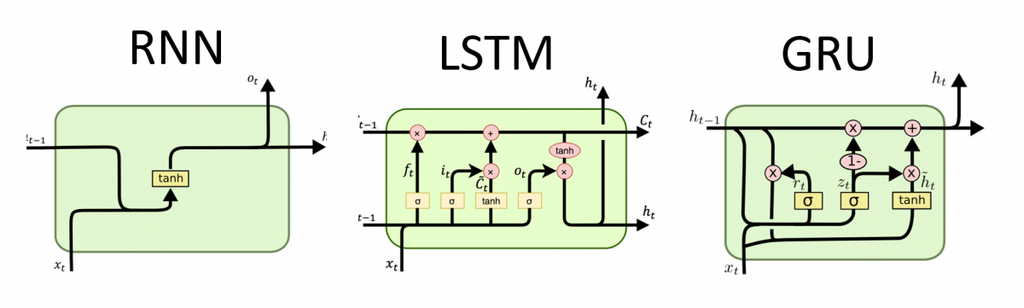

### LSTM [[Hochreiter, Schmidhuber, Long short-term memory 1997]](https://deeplearning.cs.cmu.edu/F23/document/readings/LSTM.pdf)

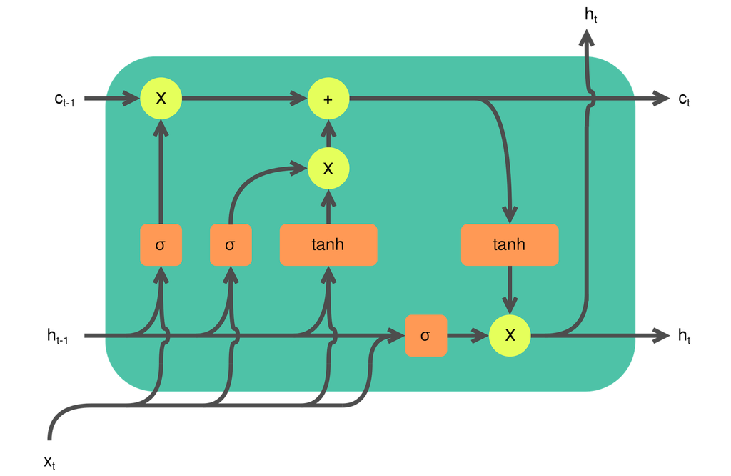

- każda komórka RNN jest zastąpiona **komórką pamięci**
  - komórka pamięci łączy się ze sobą wagą o wartości 1
  - to zapewnia, że gradient nie znika ani nie wybucha
- komórki RNN są zwykle *long-term* powoli zapamiętując ogólną wiedzę *short-term* dla efemerycznych aktywacji w szczególnych przypadkach
  - *lstm* to połączenie
- opisane w *Neural Computation*, półtora roku w recenzji!
  - obecnie ponad 92 tysiące cytowań

### Long short-term memory LSTM

- komórki mają **stan** oraz bramki mówiące czy
  - wejście powinno mieć wpływ na stan (input gate)
  - czy stan powinien być wyzerowany (forget gate)
  - czy stan powinien mieć wpływ na wyjście (output gate)

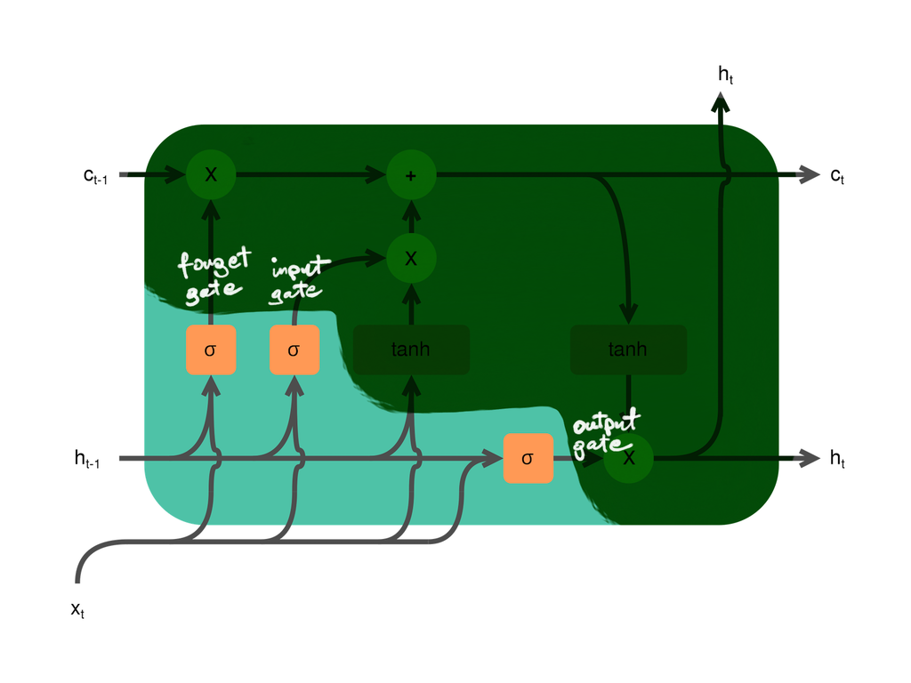

- dane są przez poprzedni stan $h_{t-1}$ i aktualne wejście $x_t$
  - te połączone dane są przetwarzane przez w pełni połączone (FC) warstwy z aktywacjami sigmoidalnymi dając aktywacje w $(0, 1)$
    - **input gate** $I_t$ jak wiele aktualnego wejścia będzie dodane do stanu wewnętrznego $$I_t=\sigma(X_tW_{xi} + H_{t-1}W_{hi}+b_i)$$
    - **forget gate** $F_t$ czy pamiętać stan komórki, czy też wyczyścić $$F_t=\sigma(X_tW_{xf} + H_{t-1}W_{hf}+b_f)$$
    - **output gate** $O_t$ czy stan komórki powinien wpływać na aktualne wyjście $$O_t=\sigma(X_tW_{xo} + H_{t-1}W_{ho}+b_o)$$

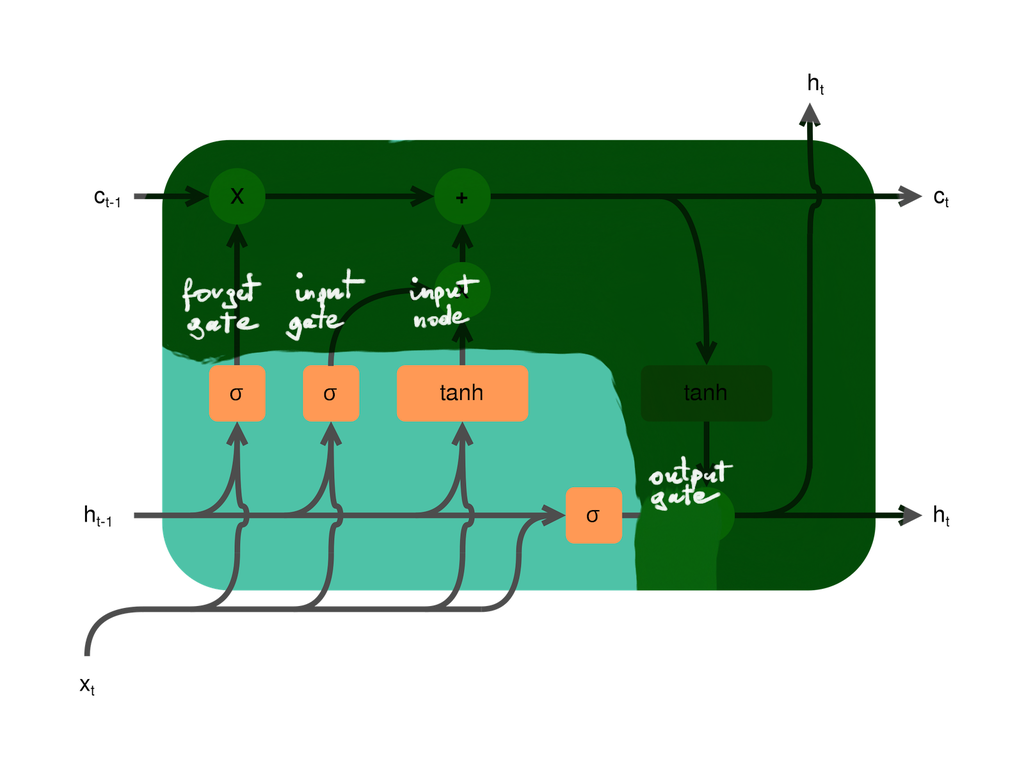

- **input node** $\tilde{C}_t$ jest wyliczane w podobny sposób, ale używając aktywacji $\tanh$ $$\tilde{C}_t=\tanh(X_tW_{xc} + H_{t-1}W_{hc}+b_c)$$

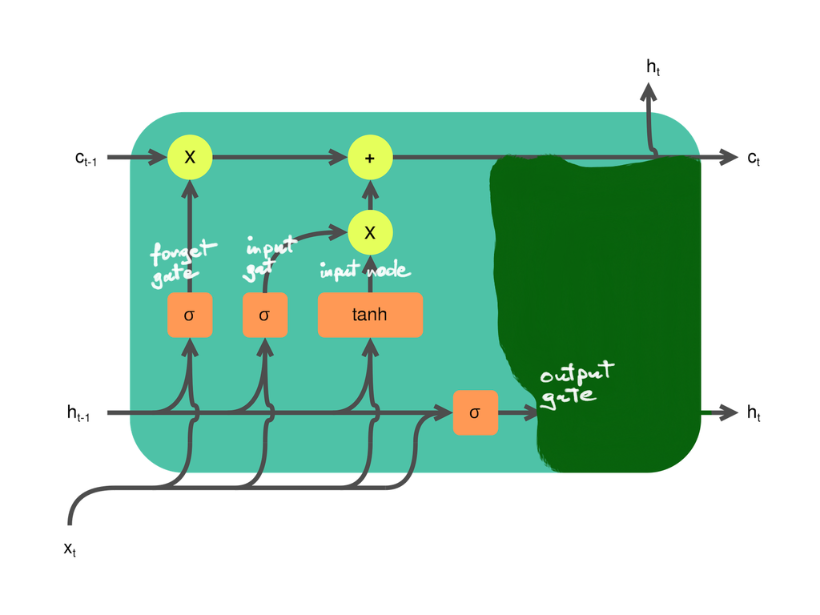

- **stan komórki** $C_{t-1}$ jest przekazywany z poprzedniego kroku
  - $I_t$ steruje jak wiele należy wziąć z aktualnego wejścia
  - $F_t$ określa jak wiele stanu wewnętrznego powinno być zachowane
  - nowy stan jest wyliczany element po elemencie (Hadamard) $$C_t=F_t\times{}C_{t-1}+I_t\times\tilde{C}_t$$
    - jeśli $F_t=1$ i $I_t=0$ zawsze, to stan $C_t$ pozostanie niezmienny
    - bramki wejściowa i zapominania są w stanie się nauczyć jak reagować
    - to pomaga sobie poradzić z problemem zanikającego gradientu!

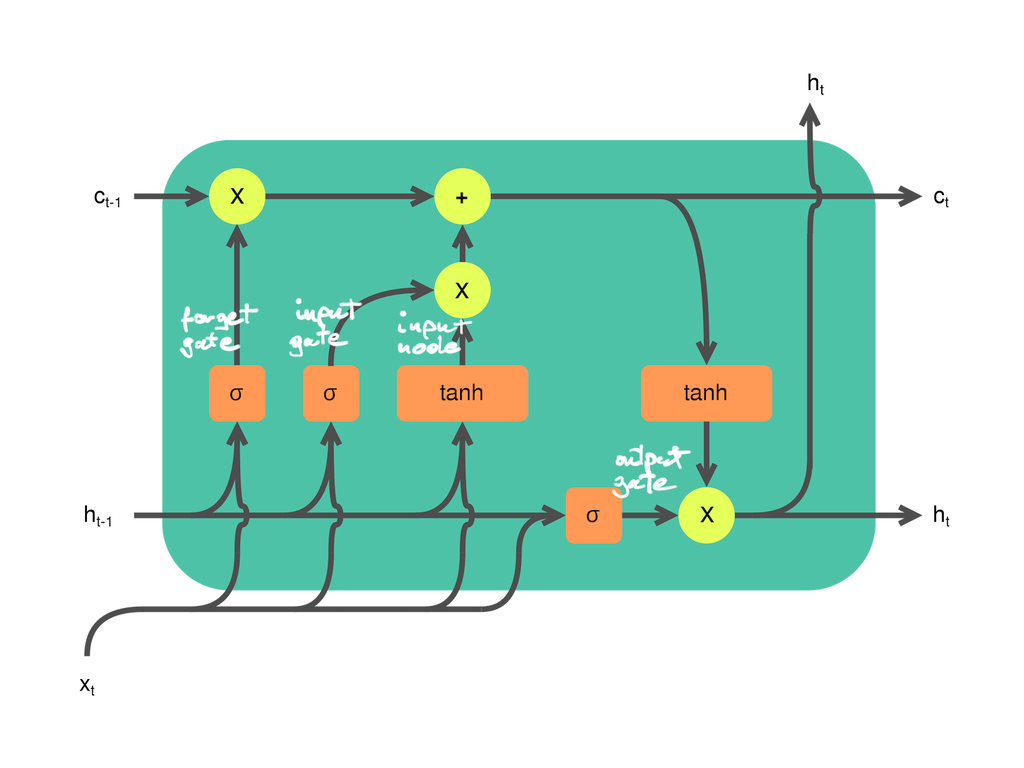

- jak stan wewnętrzny $C_t$ wpływa na stan komórki $H_t$?
  - nowo wyliczone $C_t$ jest przetwarzane nieliniowo co zapewnia, że elementy $H_t$ są zawsze w przedziale $-1,1)$
  - bramka wyjściowa steruje jak bardzo stan wewnętrzny $C_t$ wpłynie na $H_t$ $$H_t=O_t\times\tanh(C_t)$$
  - jeśli $O_t$ jest bliskie 1, to wartość $H_t$ będzie wpływać na kolejne etapy przetwarzania
  - jeśli, odwrotnie, będzie bliskie 0, to aktualny stan nie będzie wpływał na kolejne
- LSTM jest komórką z pewną pamięcią (warstwą latent) pozwalającą na precyzyjną kontrolę przetwarzania
  - przetwarzanie może być kosztowne...
  - jest trochę prostszy model GRU

### Gated recurrent unit GRU [[Cho, van Marrienboer, Bahdanau, Bengio, *On the properties of neural machine translation: encoder-decoder approaches*]](https://arxiv.org/pdf/1409.1259.pdf)

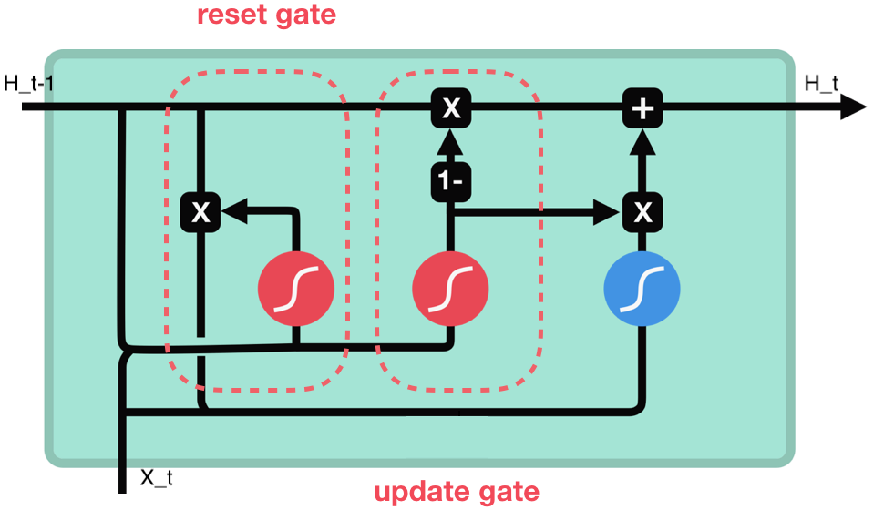

## głębokie modele RNN

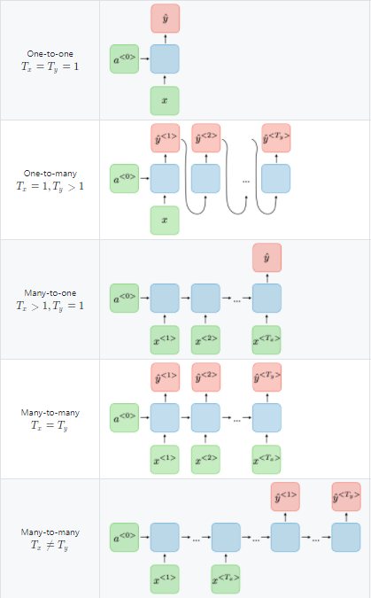

- **głębokość w czasie** odpowiada długości przetwarzanych sekwencji
- modele mogą być także **głębokie* w sensie liczby warstw modelu
  - komórka ukryta w warstwie $l$ może jako wejście brać stan ukryty z komórki w warstwie $l-1$ $$H_t^l=\phi(H_t^{l-1}W_{xh}^l+H_{t-1}^lW_{hh}+b_h^l)$$
- w możliwe jest też, że bierze jako wejście stan obliczony przez poprzednią warstwę
  - to właściwie modele ustawione w stos

## przetwarzanie w obu kierunkach w czasie [[Schuster, Paliwal, *Bidirectional recurrent neural networks*, 1997]](https://deeplearning.cs.cmu.edu/F20/document/readings/Bidirectional%20Recurrent%20Neural%20Networks.pdf)

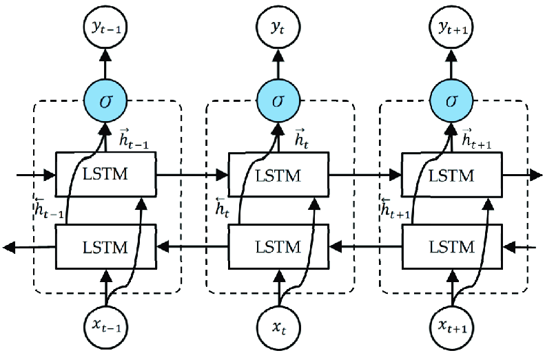

- w przetwarzaniu dla języka logiczne jest zwykle przetwarzanie token po tokenie w kierunku od wcześniejszych do następujących słów
  - ale dla niektórych języków może czasem pomóc także odwrotnie, (niemiecki?)
  - nawet w NLP wygodny jest często kontekst z obu stron
    - można uczyć z wyczyszczonymi słowami dla umiejętności wykrywania poprawnych wartości zależnych od pełnego kontekstu
- prostym rozwiązaniem jest połączenie dwóch modeli rekurencyjnych
  - **forward** przetwarza w przód generując stany ukryte $\overrightarrow{H}_t$
  - **backward** przetwarza wstecz używając $\overleftarrow{H}_t$
  - aby wygenerować wyjście $O_t$ model łączy stany ukryte $$O_t=(\overleftarrow{H}_t\mid\overrightarrow{H}_t)W_{hq}+b_q$$
- kosztowne ze względu na potrzebę przetwarzania całych sekwencji

## architektura encoder-decoder

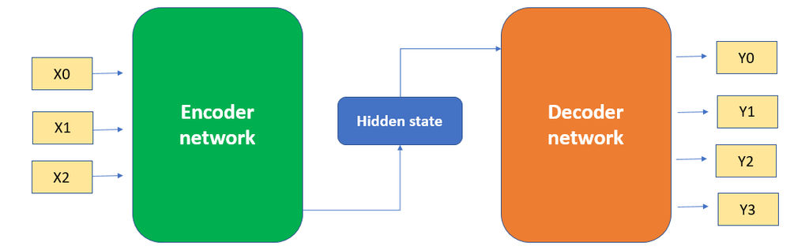

- **enkoder-dekoder** AE przetwarza przez enkoder wejście do pewnego stanu, z którego dekoder
  - może odtwarzać wejście
  - wyjście nie musi być jednak identyczne z wejściem
  - auto-enkoderem jest model U-Net

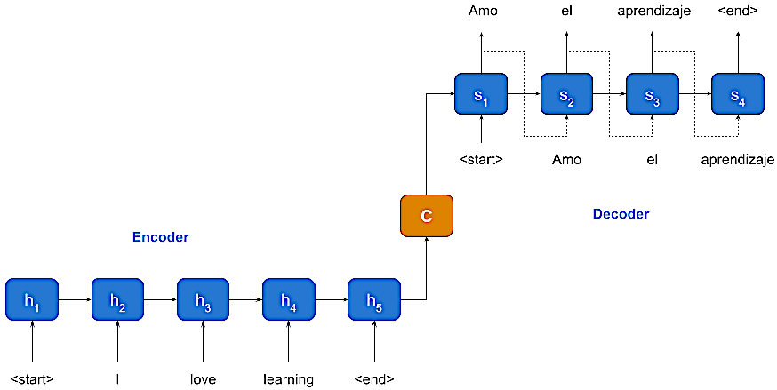